# Cosine similarity for shape/category matches

[Guillermo Montero-Melis](https://www.mpi.nl/people/montero-melis-guillermo)

13/06/2019

# 1 Introduction

As part of a critical comment on Hayakawa & Keysar (2018 in *Cognition*), we want to show that it is problematic to assume that the shape task and the category task in their Experiment 2 require the “same level of knowledge of the language” (p. 11). One reason for this is that simple co-occurrence / distributional patterns of words are predictive of semantic similarity, and thus category similarity, but not of shape similarity. To illustrate this point I want to plot the cosine similarity computed using Latent Semantic Analysis (LSA) for the shape vs category matches. LSA is not really state-of-the-art anymore, but it might be sufficient to make our point – and it has an online tool that can easily be used.

# 2 Apply LSA

## 2.1 The stimuli

```r
# The stimuli used in Experiment 2
stim <- read.csv("exp2_stimuli.csv", stringsAsFactors = FALSE)
```

Each trial in Exp 2 consisted of a triad of words. Each such triad is shown as a row in the data set:

```r
head(stim) %>% kable
```

| List | w1 | w2 | w3 | shape_match | categ_match |
| --- | --- | --- | --- | --- | --- |
| 1 | bowling ball | coconut | banana | 1-2 | 2-3 |
| 1 | apple | bowling ball | tennis racket | 1-2 | 2-3 |
| 1 | bowling ball | orange | pear | 1-2 | 2-3 |
| 1 | button | cucumber slice | toast | 1-2 | 2-3 |
| 1 | cucumber slice | wall clock | TV screen | 1-2 | 2-3 |
| 1 | TV screen | toast | pear | 1-2 | 2-3 |

Remarks:

- There were two lists with different words, each consisting of 24 trials. For each participant, one list was used for the critical shape and category tasks (the same 24 items per task, so that task was manipulated within subjects and items), while the other was used for a control task (the “picture” task, see HK18, p.11).
- For each triad, the first two words always constitute the shape match and the last two words the category match (this is also indicated in the two columns `shape_match` and `categ_match`).
- Note that some of the words are repeated across trials, e.g. “TV screen” is a category match with “wall clock” on row 5, but it is a shape match with “toast” on row 6.

## 2.2 Save stimuli to right format for LSA

We want to create a text file that has the required format for the [online LSA tool](http://lsa.colorado.edu/cgi-bin/LSA-pairwise.html) we will use.

Word pairs for which we want to compute pairwise cosine distance need to follow one another separated by a blank line.

```r
## create output file
file.create("LSA_input.txt")
```

```
## [1] TRUE
```

```r
# shape matches
for(row in seq_len(nrow(stim))) {
  cat(stim[row, "w1"], file = "LSA_input.txt", append = TRUE)
  cat("\n\n", file = "LSA_input.txt", append = TRUE)
  cat(stim[row, "w2"], file = "LSA_input.txt", append = TRUE)
  cat("\n\n", file = "LSA_input.txt", append = TRUE)
}
# category matches
for(row in seq_len(nrow(stim))) {
  cat(stim[row, "w2"], file = "LSA_input.txt", append = TRUE)
  cat("\n\n", file = "LSA_input.txt", append = TRUE)
  cat(stim[row, "w3"], file = "LSA_input.txt", append = TRUE)
  cat("\n\n", file = "LSA_input.txt", append = TRUE)
}
rm(row)
```

## 2.3 Apply LSA

Go to http://lsa.colorado.edu/cgi-bin/LSA-pairwise.html and paste the input data from the previous step (“LSA_input.txt”) into the corresponding text field. It should look something like this:

[figure not shown]

LSA: input screen

After clicking “Submit Texts”, the output is the following webbage:

[figure not shown]

LSA: output screen (first five pairwise comparisons shown)

For each consecutive pair of words there is a cosine distance. This html file has been saved to the repository as “LSA_output_raw-html.html”. The next step is to extract the cosine values for each comparison.

## 2.4 Cast cosine similarities into convenient data format

We want to cast the crucial information from the html file into a convenient format, i.e. into a tabular format.

### 2.4.1 Define the format we want to achieve

First, let’s create a dataframe with the right format but without the cosine distances (these we’ll add in the next step).

```r
# Put shape matches and category matches into one column each
stim$shape <- with(stim, paste(w1, w2, sep = " - "))
stim$category <- with(stim, paste(w2, w3, sep = " - "))
# keep only necessary columns and reshape to long format
cosines <- stim %>%
  select(List, shape, category) %>%
  gather(match_type, word_pair, shape, category)
```

For now the dataframe looks like this (first and last 3 rows):

```r
head(cosines, 3)
```

```
##   List match_type              word_pair
## 1    1      shape bowling ball - coconut
## 2    1      shape   apple - bowling ball
## 3    1      shape  bowling ball - orange
```

```r
tail(cosines, 3)
```

```
##    List match_type                     word_pair
## 94    2   category microphone - computer monitor
## 95    2   category headphones - computer monitor
## 96    2   category              lollipop - candy
```

### 2.4.2 Extract the important info from html file

I will apply a bit of a brute force approach: We’ll read the html file as text and use REGEX to extract the actual results. (R packages such as `XML` might do this in a more structured way but for our purposes, REGEX will do the job.)

First, read the html file line-by-line and put it into a data frame of one single column.

```r
lsa_out <- read.delim("LSA_output_raw-html.html", header = FALSE, sep = ",",
                      col.names = "text", stringsAsFactors = FALSE)
# Note that by using sep = "," we're making sure each line in the file becomes
# one line in our data frame
head(lsa_out)
```

```
##                                                                                                                                     text
## 1                                                      <!-- saved from url=(0051)http://lsa.colorado.edu/cgi-bin/LSA-pairwise-x.html -->
## 2 <html><head><meta http-equiv=Content-Type content=text/html; charset=windows-1252><title>Latent Semantic Analysis at CU</title></head>
## 3                                                                                <body background=./LSA_output_raw-html_files/chalk.jpg>
## 4                                                                                                   <h3>Pairwise Comparison Results</h3>
## 5                                                                  \t\tThe submitted texts' similarity (in <b>term to term</b> space):<br>
## 6                                                                                                                        <table border=>
```

Inspecting the html (in a separate text editor like SublimeText), we can easily identify which rows contain the crucial information, that is, the words that were compared or their cosine similarity: These happen to be all the rows that contain the word “align” in them (because the crucial information appears in a table format). So let’s use this to select only relevant rows.

```r
# NB: Using the pipes with dplyr ensures the result is not turned from a
# dataframe into a vector
lsa_out <- lsa_out %>%
  filter(grepl("align", text))
head(lsa_out)
```

```
##                                                                       text
## 1       <tbody><tr> <td align=CENTER>Texts </td><td align=CENTER> coconut
## 2 </td></tr><tr> <td align=CENTER> bowling ball</td><td align=CENTER> 0.04
## 3  <tbody><tr> <td align=CENTER>Texts </td><td align=CENTER> bowling ball
## 4        </td></tr><tr> <td align=CENTER> apple</td><td align=CENTER> 0.18
## 5        <tbody><tr> <td align=CENTER>Texts </td><td align=CENTER> orange
## 6 </td></tr><tr> <td align=CENTER> bowling ball</td><td align=CENTER> 0.07
```

```r
# Now we put each pair of consecutive rows together, so that all info for a
# triad is in the same line:
odd_rows <- -1 + 2 * seq_len(nrow(lsa_out) / 2)
lsa_comb <- data.frame(odd  = lsa_out$text[odd_rows],
                       even = lsa_out$text[odd_rows + 1])
lsa_combined <- with(lsa_comb, paste(odd, even))
rm(odd_rows, lsa_comb)
```

This is already some progress: the information for each comparison (i.e., the two words and their cosine distance) is in one separate row. Only it is buried in lots of html markup, so let’s remove it:

```r
# Unwieldy regex, but does the job. We are matching the whole line, while
# capturing the info that interests us in parentheses; this allows us to
# substitute the whole string with just the relevant info using backreferences
# (e.g., "\\1"). Note that we need to take into account that:
# 1) The target word sometimes consists of two words ("TV screen");
# 2) Some cosine similarities are NA (marked as "N/A") because the word isn't
#    in the corpus.
lsa_clean <- gsub(".*xts.*ER> ([A-Za-z]+ ?[A-Za-z]*)  .*ER> ([A-Za-z]+ ?[A-Za-z]*)<.*([0-9]\\.[0-9]+|N/A)$",
                  "\\2 - \\1,\\3", lsa_combined, perl = TRUE)
# We replace the 1st and 2nd word in reversed order to match the original order
# (simply a consequence of how html of tables is parsed but of course
# cosine(A,B) = cosine(B,A) so it doesn't matter).
lsa_clean <- data.frame(collapsed = lsa_clean) %>%
  separate(collapsed, c("word_pair", "cosine"), ",")
lsa_clean$cosine <- as.numeric(lsa_clean$cosine)
head(lsa_clean)
```

```
##                     word_pair cosine
## 1      bowling ball - coconut   0.04
## 2        apple - bowling ball   0.18
## 3       bowling ball - orange   0.07
## 4     button - cucumber slice   0.00
## 5 cucumber slice - wall clock   0.12
## 6           TV screen - toast   0.08
```

### 2.4.3 Merge it back to the intended data frame

And finally…

```r
cosines <- left_join(cosines, lsa_clean)
head(cosines)
```

```
##   List match_type                   word_pair cosine
## 1    1      shape      bowling ball - coconut   0.04
## 2    1      shape        apple - bowling ball   0.18
## 3    1      shape       bowling ball - orange   0.07
## 4    1      shape     button - cucumber slice   0.00
## 5    1      shape cucumber slice - wall clock   0.12
## 6    1      shape           TV screen - toast   0.08
```

There are 5 NAs (or 5% of the word pairs).

# 3 Add cosine distances computed by Jeroen van Paridon

These were computed using the sub2vec approach, which combines the state-of-the-art word2vec algorithms with the data from SUBTLEX-US.

```r
cosine_s2v <- read.delim("exp2_stimuli_with_cosine_sub2vec.tsv",
                         stringsAsFactors = FALSE, row.names = 1) %>%
  rename(match_type = condition, cosine_s2v = cosine.similarity)
head(cosine_s2v)
```

```
##               w1             w2            w3 match_type cosine_s2v
## 0   bowling ball        coconut        banana   category  0.7138869
## 1          apple   bowling ball tennis racket   category         NA
## 2   bowling ball         orange          pear   category  0.3706316
## 3         button cucumber slice         toast   category         NA
## 4 cucumber slice     wall clock     TV screen   category         NA
## 5      TV screen          toast          pear   category  0.3019101
```

```r
# transform so we can join it with cosines
cosine_s2v$word_pair <- ""
cosine_s2v[cosine_s2v$match_type == "shape", "word_pair"] <-
  with(cosine_s2v[cosine_s2v$match_type == "shape", ], paste(w1, w2, sep = " - "))
cosine_s2v[cosine_s2v$match_type == "category", "word_pair"] <-
  with(cosine_s2v[cosine_s2v$match_type == "category", ], paste(w2, w3, sep = " - "))
```

```r
# join
cosines <- left_join(cosines, cosine_s2v %>% select(word_pair, match_type, cosine_s2v))
head(cosines)
```

```
##   List match_type                   word_pair cosine cosine_s2v
## 1    1      shape      bowling ball - coconut   0.04         NA
## 2    1      shape        apple - bowling ball   0.18         NA
## 3    1      shape       bowling ball - orange   0.07         NA
## 4    1      shape     button - cucumber slice   0.00         NA
## 5    1      shape cucumber slice - wall clock   0.12         NA
## 6    1      shape           TV screen - toast   0.08         NA
```

# 4 Plot the result

Correlation between cosine similarity from LSA and Sub2vec

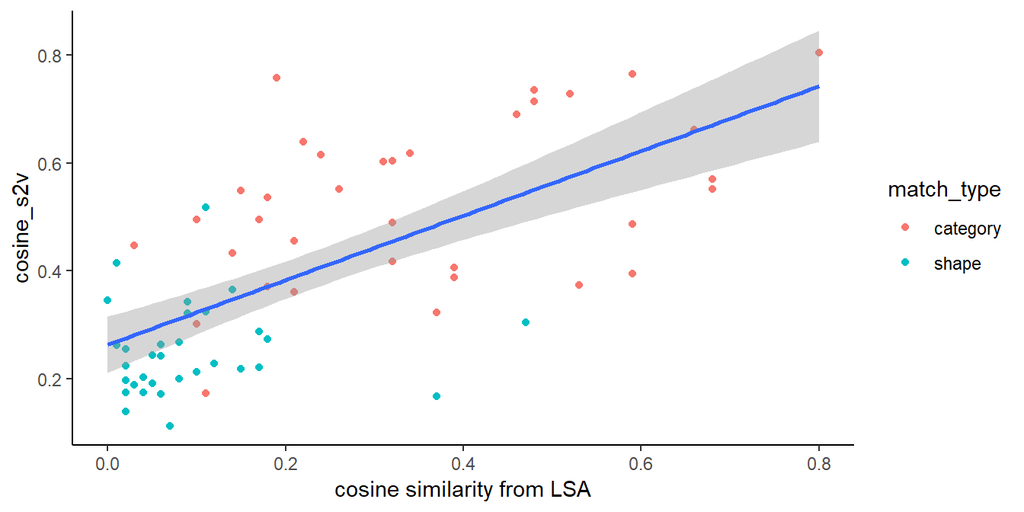

```r
ggplot(cosines, aes(x = cosine, y = cosine_s2v)) +
  geom_point(aes(colour = match_type)) +
  geom_smooth(method = "lm") +
  xlab("cosine similarity from LSA") +
  theme_classic()
```

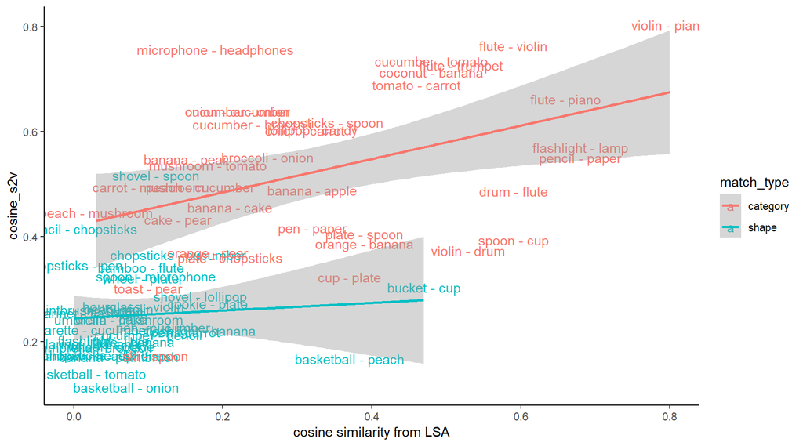

```r
ggplot(cosines, aes(x = cosine, y = cosine_s2v, colour = match_type,
                    label = word_pair)) +
  # geom_point() +
  geom_text() +
  geom_smooth(method = "lm") +
  xlab("cosine similarity from LSA") +
  theme_classic()
```

## 4.1 Simple dot plot with CIs

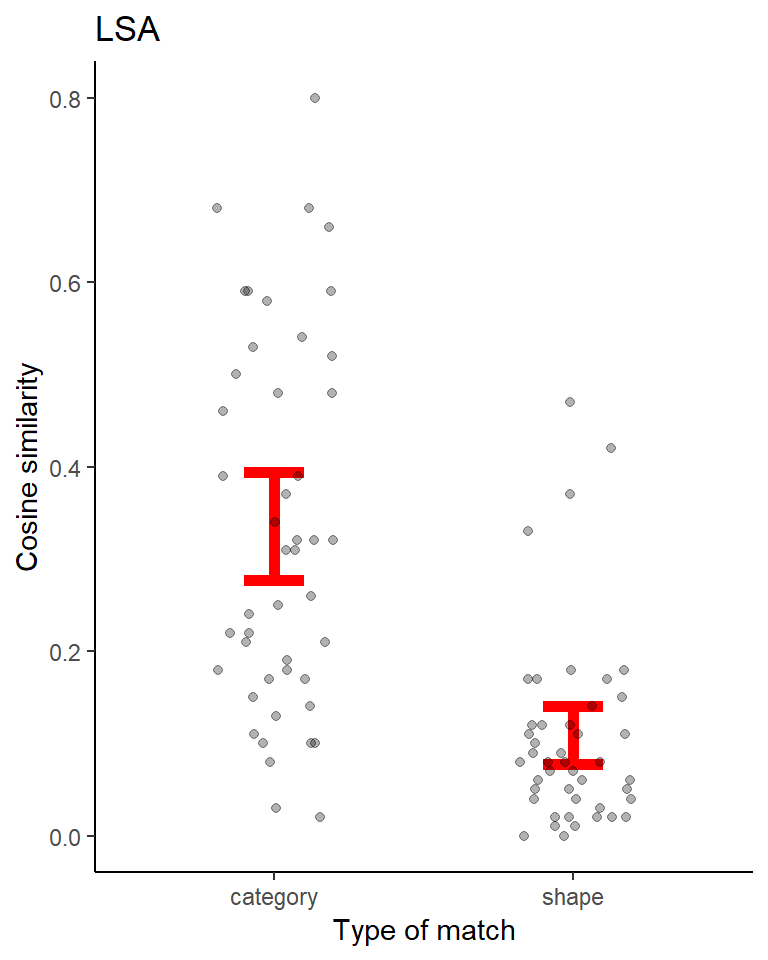

```r
ggplot(cosines, aes(x = match_type, y = cosine)) +
  stat_summary(fun.data = mean_cl_boot, geom = "errorbar", colour = "red",
               width = .2, size = 2) +
  geom_jitter(height = 0, width = .2, alpha = .3) +
  xlab("Type of match") +
  ylab("Cosine similarity") +
  ggtitle("LSA") +
  theme_classic()
```

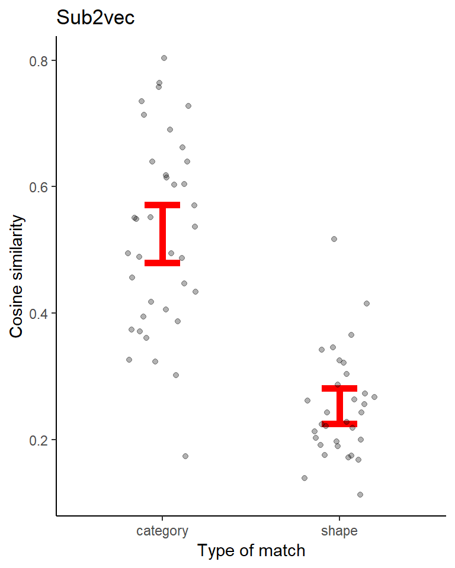

```r
ggplot(cosines, aes(x = match_type, y = cosine_s2v)) +
  stat_summary(fun.data = mean_cl_boot, geom = "errorbar", colour = "red",
               width = .2, size = 2) +
  geom_jitter(height = 0, width = .2, alpha = .3) +
  xlab("Type of match") +
  ylab("Cosine similarity") +
  ggtitle("Sub2vec") +
  theme_classic()
```

## 4.2 Plotting word pairs

Showing the word pairs instead of simple points:

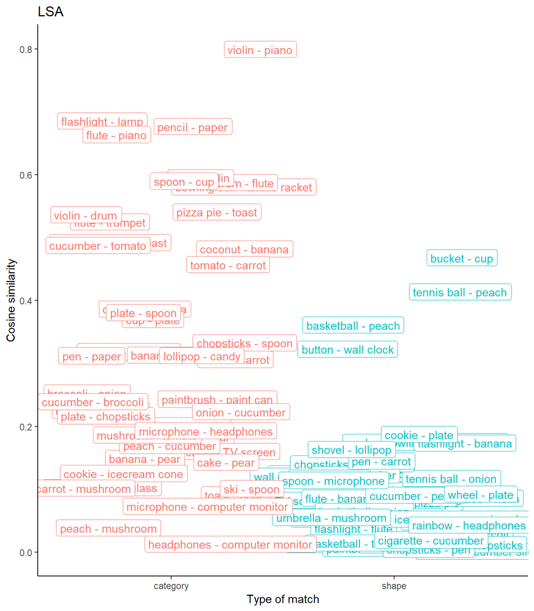

```r
# plot with labels
ggplot(cosines, aes(x = match_type, y = cosine, label = word_pair, colour = match_type)) +
  # geom_jitter(height = 0, width = .2, alpha = .3) +
  geom_label(position = position_jitter(width = .4, height = .01)) +
  xlab("Type of match") +
  ylab("Cosine similarity") +
  ggtitle("LSA") +
  theme_classic() +
  theme(legend.position="none")
```

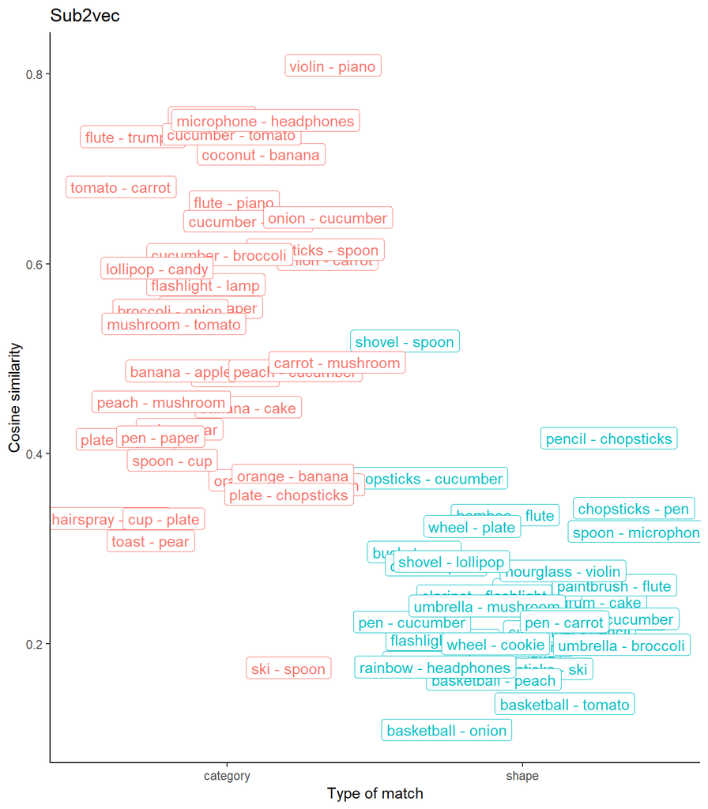

```r
ggplot(cosines, aes(x = match_type, y = cosine_s2v, label = word_pair, colour = match_type)) +
  # geom_jitter(height = 0, width = .2, alpha = .3) +
  geom_label(position = position_jitter(width = .4, height = .01)) +
  xlab("Type of match") +
  ylab("Cosine similarity") +
  ggtitle("Sub2vec") +
  theme_classic() +
  theme(legend.position="none")
```

## 4.3 Plot labels for extreme values only

It might be nice to label only the more extreme points:

```r
# Create the labels for extreme points -- note these differ depending on
# LSA vs sub2vec!
# Labels for extreme values
# LSA
cosines$Labels_lsa <- cosines$word_pair
cosines$Labels_lsa[with(cosines,
                        match_type == "category" &
                          ! (cosine <= .05 | cosine > .65) )] <- NA
cosines$Labels_lsa[with(cosines,
                        match_type == "shape" &
                          ! (cosine <= .005 | cosine > .35) )] <- NA
# sub2vec
cosines$Labels_s2v <- cosines$word_pair
cosines$Labels_s2v[with(cosines,
                        match_type == "category" &
                          ! (cosine_s2v <= .35 | cosine_s2v > .65) )] <- NA
cosines$Labels_s2v[with(cosines,
                        match_type == "shape" &
                          ! (cosine_s2v <= .17 | cosine_s2v > .35) )] <- NA
```

Plot

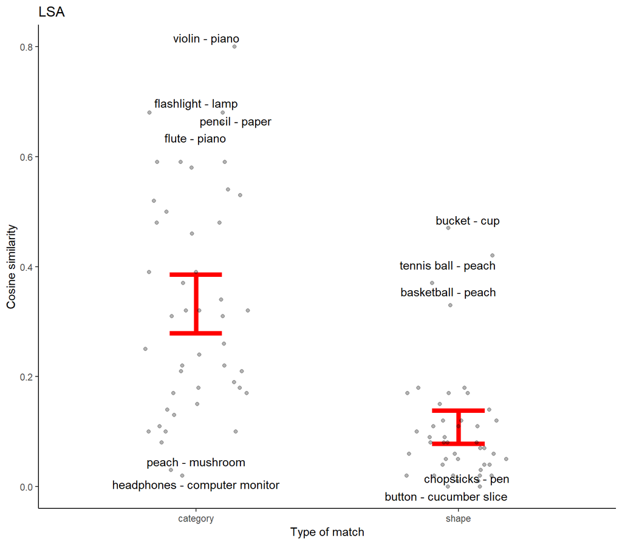

```r
# plot with labels
ggplot(cosines, aes(x = match_type, y = cosine, label = Labels_lsa)) +
  stat_summary(fun.data = mean_cl_boot, geom = "errorbar", colour = "red",
               width = .2, size = 2) +
  geom_jitter(height = 0, width = .2, alpha = .3) +
  geom_text_repel() +
  xlab("Type of match") +
  ylab("Cosine similarity") +
  ggtitle("LSA") +
  theme_classic()
```

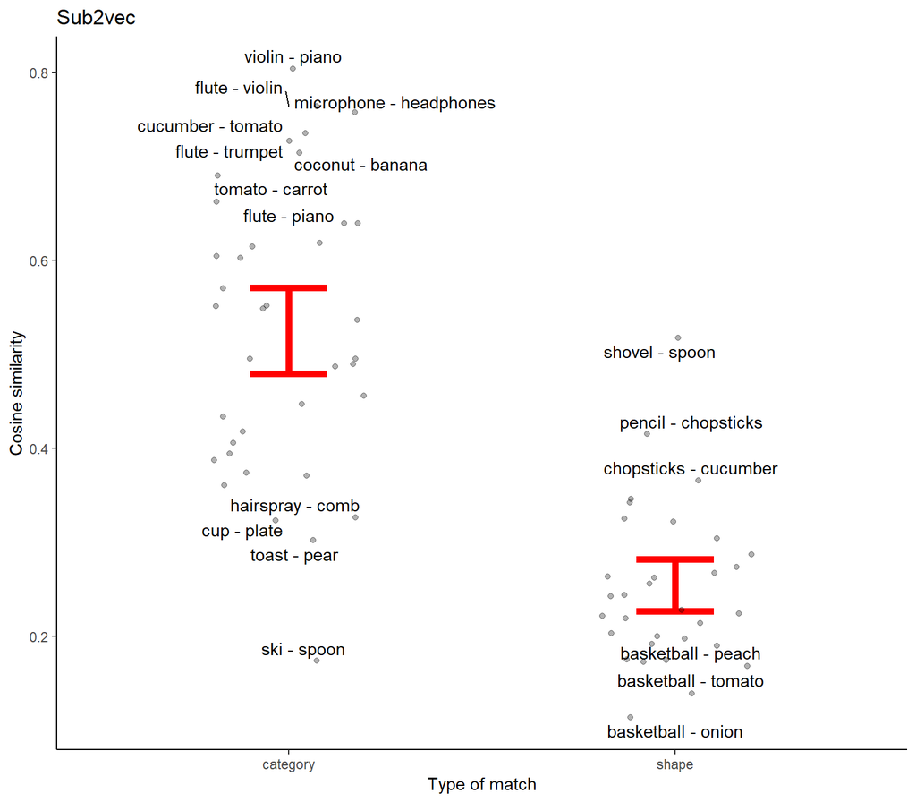

```r
ggplot(cosines, aes(x = match_type, y = cosine_s2v, label = Labels_s2v)) +
  stat_summary(fun.data = mean_cl_boot, geom = "errorbar", colour = "red",
               width = .2, size = 2) +
  geom_jitter(height = 0, width = .2, alpha = .3) +
  geom_text_repel() +
  xlab("Type of match") +
  ylab("Cosine similarity") +
  ggtitle("Sub2vec") +
  theme_classic()
```